# Stage type data

# SETUP

Load libraries.

```r
library(tidyverse)
library(rvest)
library(lubridate)
library(geosphere)
library(geonames)
library(maps)
library(mapproj)
library(XML)
library(methods)
```

# SCRAPE

Create vector of the Tour de FRnce wikipedia URLs from [wikipedia](https://en.wikipedia.org/wiki/2005_Tour_de_France) site (link is for 2005 as an example).

```r
years <- seq(1903, 2019, 1)
url_base <- "https://en.wikipedia.org/wiki/"
url_end <- "_Tour_de_France"
urls <- years %>%
  paste0(url_base, . , url_end)

data_init <- tibble(year = years, url_path = urls)

data_init
```

| year | url_path |
| --- | --- |
| 1903 | https://en.wikipedia.org/wiki/1903_Tour_de_France |
| 1904 | https://en.wikipedia.org/wiki/1904_Tour_de_France |
| 1905 | https://en.wikipedia.org/wiki/1905_Tour_de_France |
| 1906 | https://en.wikipedia.org/wiki/1906_Tour_de_France |
| 1907 | https://en.wikipedia.org/wiki/1907_Tour_de_France |
| 1908 | https://en.wikipedia.org/wiki/1908_Tour_de_France |
| 1909 | https://en.wikipedia.org/wiki/1909_Tour_de_France |
| 1910 | https://en.wikipedia.org/wiki/1910_Tour_de_France |
| 1911 | https://en.wikipedia.org/wiki/1911_Tour_de_France |
| 1912 | https://en.wikipedia.org/wiki/1912_Tour_de_France |

[output cut: 107 more lines]

```r
urls[1:20]
```

```
 [1] "https://en.wikipedia.org/wiki/1903_Tour_de_France" "https://en.wikipedia.org/wiki/1904_Tour_de_France"
 [3] "https://en.wikipedia.org/wiki/1905_Tour_de_France" "https://en.wikipedia.org/wiki/1906_Tour_de_France"
 [5] "https://en.wikipedia.org/wiki/1907_Tour_de_France" "https://en.wikipedia.org/wiki/1908_Tour_de_France"
 [7] "https://en.wikipedia.org/wiki/1909_Tour_de_France" "https://en.wikipedia.org/wiki/1910_Tour_de_France"
 [9] "https://en.wikipedia.org/wiki/1911_Tour_de_France" "https://en.wikipedia.org/wiki/1912_Tour_de_France"
[11] "https://en.wikipedia.org/wiki/1913_Tour_de_France" "https://en.wikipedia.org/wiki/1914_Tour_de_France"
[13] "https://en.wikipedia.org/wiki/1915_Tour_de_France" "https://en.wikipedia.org/wiki/1916_Tour_de_France"
[15] "https://en.wikipedia.org/wiki/1917_Tour_de_France" "https://en.wikipedia.org/wiki/1918_Tour_de_France"
[17] "https://en.wikipedia.org/wiki/1919_Tour_de_France" "https://en.wikipedia.org/wiki/1920_Tour_de_France"
[19] "https://en.wikipedia.org/wiki/1921_Tour_de_France" "https://en.wikipedia.org/wiki/1922_Tour_de_France"
```

Define function to scrape and clean Tour de FRnce data from one URL.

```r
scrape_wiki <- function(url, table_n = 2){

  xpath_start <- '//*[@id="mw-content-text"]/div/table['
  xpath_end <-']'
  xpath_full <- paste0(xpath_start, table_n, xpath_end)

xml <- url %>%
  read_html() %>%
  html_nodes(xpath = xpath_full) %>%
  html_table(fill = TRUE)

xml[[1]]
}
```

Scrape data for every year.

```r
data <- data_init %>%
  mutate(year_data = purrr::map(url_path, possibly(scrape_wiki, "no data")))
data
```

| year | url_path | year_data |
| --- | --- | --- |
| 1903 | https://en.wikipedia.org/wiki/1903_Tour_de_France |  |
| 1904 | https://en.wikipedia.org/wiki/1904_Tour_de_France |  |
| 1905 | https://en.wikipedia.org/wiki/1905_Tour_de_France |  |
| 1906 | https://en.wikipedia.org/wiki/1906_Tour_de_France |  |
| 1907 | https://en.wikipedia.org/wiki/1907_Tour_de_France |  |
| 1908 | https://en.wikipedia.org/wiki/1908_Tour_de_France |  |
| 1909 | https://en.wikipedia.org/wiki/1909_Tour_de_France |  |
| 1910 | https://en.wikipedia.org/wiki/1910_Tour_de_France |  |
| 1911 | https://en.wikipedia.org/wiki/1911_Tour_de_France |  |
| 1912 | https://en.wikipedia.org/wiki/1912_Tour_de_France |  |

[output cut: 107 more lines]

Manual corrections to xpath for 1905 and 1907 as bringing in incorrect table. Looked on wikipedia pages to find xpaths for these. Difference that not 2nd table on page, 3rd table for 1905 and 4th for 1907.

```r
data$year_data[[3]] <- scrape_wiki(data$url_path[[3]], table_n = 3)
data$year_data[[5]] <- scrape_wiki(data$url_path[[5]], table_n = 4)
```

Filter out datasets with no data (due to world wars).

```r
has_data <- function(ls){
  !has_element(ls, "no data")
}

data <- data %>%
  mutate(data_exists = map_lgl(year_data, has_data)) %>%
  filter(data_exists) %>%
  select(-data_exists)
```

Write function to clean each dataset into the same shape with same column headings. Apply this to every dataset.

```r
clean_wiki <- function(df) {
  df <- df %>%
    setNames(make.names(names(.), unique = TRUE)) %>%
    select(1:4, 6:7)

  names(df) <- c("stage", "date", "course", "distance_km", "terrain", "winner")

  df
}

data <- data %>%
  mutate(year_data = purrr::map(year_data, clean_wiki))
```

Combine datasets for different years together.

```r
char_stage <- function(df){
  df %>% mutate(stage = as.character(stage))
}

data <- data %>%
  mutate(year_data = purrr::map(year_data, char_stage)) %>%
  select(year, year_data) %>%
  unnest()
```

Separate the columns of each dataset where neccessary.

```r
data_sep <- data %>%
  filter(date != "Total") %>%
  separate(date, into = c("day", "month"), sep = " ") %>%
  separate(course, into = c("start", "end"), sep = " to ") %>%
  separate(distance_km,
           into = c("distance_km", "dist_rm"),
           sep = "km") %>%
  separate(winner, into = c("winner_name", "winner_country"), sep = "\\(") %>%
  select(-dist_rm)
```

```
Expected 2 pieces. Additional pieces discarded in 1 rows [571].Expected 2 pieces. Missing pieces filled with `NA` in 294 rows [441, 447, 452, 457, 470, 476, 484, 486, 500, 505, 508, 514, 516, 518, 535, 540, 542, 549, 553, 555, ...].Expected 2 pieces. Missing pieces filled with `NA` in 159 rows [441,…
```

Combine year, month and day into one date field.

```r
data_sep <- data_sep %>%
  mutate(date = paste0(year, month, day),
         date = parse_date(date, format = "%Y%B%d"))
```

```
1 parsing failure.
row col         expected actual
571  -- date like %Y%B%d  19389
```

```r
# Filter any errors
filter(data_sep, is.na(date))
```

| year | stage | day | month | start | end | distance_km | terrain | winner_name | winner_country | date |
| --- | --- | --- | --- | --- | --- | --- | --- | --- | --- | --- |
| 1938 |  | 9 |  | Royan | NA | Royan | Rest day | Rest day | NA |  |

```r
# Error in 1938, month is blank for one of the rest days - should be July.
filter(data_sep, year == 1938)
```

| year | stage | day | month | start | end | distance_km | terrain | winner_name | winner_country | date |
| --- | --- | --- | --- | --- | --- | --- | --- | --- | --- | --- |
| 1938 | 1 | 5 | July | Paris | Caen | 215 | Plain stage | Willi Oberbeck | GER) | 1938-07-05 |
| 1938 | 2 | 6 | July | Caen | Saint-Brieuc | 237 | Plain stage | Jean Majerus | LUX) | 1938-07-06 |
| 1938 | 3 | 7 | July | Saint-Brieuc | Nantes | 238 | Plain stage | Gerrit Schulte | NED) | 1938-07-07 |
| 1938 | 4a | 8 | July | Nantes | La Roche-sur-Yon | 62 | Plain stage | Éloi Meulenberg | BEL) | 1938-07-08 |
| 1938 | 4b | 8 | July | La Roche-sur-Yon | La Rochelle | 83 | Plain stage | Éloi Meulenberg | BEL) | 1938-07-08 |
| 1938 | 4c | 8 | July | La Rochelle | Royan | 83 | Plain stage | Félicien Vervaecke | BEL) | 1938-07-08 |
| 1938 |  | 9 |  | Royan | NA | Royan | Rest day | Rest day | NA |  |
| 1938 | 5 | 10 | July | Royan | Bordeaux | 198 | Plain stage | Éloi Meulenberg | BEL) | 1938-07-10 |
| 1938 | 6a | 11 | July | Bordeaux | Arcachon | 53 | Plain stage | Jules Rossi | ITA) | 1938-07-11 |
| 1938 | 6b | 11 | July | Arcachon | Bayonne | 171 | Plain stage | Glauco Servadei | ITA) | 1938-07-11 |

[output cut: 25 more lines]

```r
# Correction to set month to prev stage month if error
data_sep <- data_sep %>%
  mutate(month = if_else((month %in% month.name), month, lag(month)))

# Rerun date parsing and check for errors
data_sep <- data_sep %>%
  mutate(date = paste0(year, month, day),
         date = parse_date(date, format = "%Y%B%d"))

filter(data_sep, is.na(date))
```

| year | stage | day | month | start | end | distance_km | terrain | winner_name | winner_country | date |
| --- | --- | --- | --- | --- | --- | --- | --- | --- | --- | --- |

```r
# Show any rows where dates are not in order expected given row position.  These are due to incorrect dates for rest days.
data_sep %>%
  group_by(year) %>%
  mutate(not_after_prev = (date < lag(date)),
         not_before_next = (date > lead(date))) %>%
  filter(not_after_prev | not_before_next)
```

| year | stage | day | month | start | end | distance_km | terrain | winner_name | winner_country | date | not_after_prev | not_before_next |
| --- | --- | --- | --- | --- | --- | --- | --- | --- | --- | --- | --- | --- |
| 1936 | 15 | 25 | July | Perpignan | Luchon | 325 | Stage with mountain(s) | Sauveur Ducazeaux | FRA) | 1936-07-25 | FALSE | TRUE |
| 1936 |  | 14 | July | Luchon | NA | Luchon | Rest day | Rest day | NA | 1936-07-14 | TRUE | FALSE |
| 1937 |  | 22 | July | Pau | NA | Pau | Rest day | Rest day | NA | 1937-07-22 | FALSE | TRUE |
| 1937 | 16 | 21 | July | Pau | Bordeaux | 235 | Plain stage | Paul Chocque | FRA) | 1937-07-21 | TRUE | FALSE |
| 1950 | 10 | 23 | July | Bordeaux | Pau | 202 | Plain stage | Marcel Dussault | FRA) | 1950-07-23 | FALSE | TRUE |
| 1950 | NA | 22 | July | Pau | NA | Pau | Rest day | Rest day | NA | 1950-07-22 | TRUE | FALSE |
| 2005 | 10 | 12 | July | Grenoble | Courchevel | 177.0 | Mountain stage | Alejandro Valverde | ESP) | 2005-07-12 | FALSE | TRUE |
| 2005 | NA | 11 | July | Grenoble | NA | Grenoble | Rest day | Rest day | NA | 2005-07-11 | TRUE | FALSE |
| 2005 | 16 | 19 | July | Mourenx | Pau | 180.5 | Mountain stage | Óscar Pereiro | ESP) | 2005-07-19 | FALSE | TRUE |
| 2005 | NA | 13 | July | Pau | NA | Pau | Rest day | Rest day | NA | 2005-07-13 | TRUE | FALSE |

```r
# Correct rest day dates manually as there is not a systematic reason they are incorrect (2005 rest day is out by 5 days and in wrong place).
data_sep <- data_sep %>%
  mutate(date = if_else(((year == 1936) & (day == "14") & (month == "July") & (start == "Luchon") & (terrain == "Rest day")), make_date(year = 1936, month = 7, day = 26L), date),
         date = if_else(((year == 1937) & (day == "22") & (month == "July") & (start == "Pau") & (terrain == "Rest day")), make_date(year = 1937, month = 7, day = 20L), date),
         date = if_else(((year == 1950) & (day == "22") & (month == "July") & (start == "Pau") & (terrain == "Rest day")), make_date(year = 1950, month = 7, day = 24L), date),
         date = if_else(((year == 2005) & (day == "13") & (month == "July") & (start == "Pau") & (terrain == "Rest day")), make_date(year = 2005, month = 7, day = 18L), date),
         start = if_else(((year == 2005) & (day == "13") & (month == "July") & (start == "Pau") & (terrain == "Rest day")), "Mourenx", start))

filter(data_sep, is.na(date))
```

| year | stage | day | month | start | end | distance_km | terrain | winner_name | winner_country | date |
| --- | --- | --- | --- | --- | --- | --- | --- | --- | --- | --- |

Clean rest day rows. There are rows for rest days, these have NA for ‘end’ because the Tour didn’t go anywhere on these days.

```r
# Clean rest day rows
data_rest <- data_sep %>%
  filter(terrain == "Rest day") %>%
  mutate(end = start, distance_km = "0", winner_name = NA, winner_country = NA, stage = NA)

data_sep <- data_sep %>%
  filter(terrain != "Rest day") %>%
  bind_rows(data_rest)
```

Clean stage field. Create separate stage_number and sub_stage fields. Create stage_id to uniquely define each row.

```r
unique(data_sep$stage)
```

```
 [1] "1"   "2"   "3"   "4"   "5"   "6"   "7"   "8"   "9"   "10"  "11"  "12"  "13"  "14"  "15"  "16"  "17"  "18"  "19"  "20"  "21"  "22"
[23] "23"  "24"  "21a" "21b" "5a"  "5b"  "13a" "13b" "14a" "14b" "18a" "18b" "19a" "19b" "20a" "20b" "19c" "5c"  "11a" "11b" "12a" "12b"
[45] "14c" "17a" "17b" "17c" "4a"  "4b"  "4c"  "6a"  "6b"  "10a" "10b" "10c" "20c" "2a"  "2b"  "8a"  "8b"  "16a" "16b" "16c" "1a"  "1b"
[67] "3a"  "3b"  "15a" "15b" "22a" "22b" "P"   "7a"  "7b"  "1c"  "9a"  "9b"  "18c" "25"  NA
```

```r
data_sep <- data_sep %>%
  mutate(stage_id = paste(year, stage, sep = "_"),
         stage_number = as.integer(str_extract(stage, "\\d+")),
         sub_stage = if_else(stage == "P", "P", str_extract(stage, "[a-z]")),
         sub_stage = if_else((!is.na(stage) & is.na(sub_stage)), "main", sub_stage),
         stage_number = if_else(sub_stage == "P", 0L, stage_number)
  )

unique(data_sep$stage_number)
```

```
 [1]  1  2  3  4  5  6  7  8  9 10 11 12 13 14 15 16 17 18 19 20 21 22 23 24  0 25 NA
```

```r
unique(data_sep$sub_stage)
```

```
[1] "main" "a"    "b"    "c"    "P"    NA
```

```r
filter(data_sep, is.na(stage_number) & terrain != "Rest day")
```

| year | stage | day | month | start | end | distance_km | terrain | winner_name | winner_country | date | stage_id | stage_number | sub_stage |
| --- | --- | --- | --- | --- | --- | --- | --- | --- | --- | --- | --- | --- | --- |

```r
# check stage_id unique for each row.
data_sep %>%
  select(stage_id) %>%
  distinct() %>%
  summarise(n = n())
```

| n |
| --- |
| 2353 |

```r
nrow(data_sep)
```

```
[1] 2437
```

Clean start and end locations. First see which locations are NA for end. Most of these are short time trial stages, so it makes sense that they have NA end location, as end location will be same as start. Set end location to start location if terrain contains “time”.

For the remaining stages that have no end location, review each on the Tour de FRnce website and see if any shouldn’t be set to start location. This is ok for all of the stages apart from 2007 stage 3 and 2013 stage 9 which have two locations in the ‘start’ column, as the locations are not separated by " to " but by dashes. Set end to start for all and then adjust these two manually.

Split start and end location into start_place, start_country, end_place, end_country. This information is recorded in the location as (country) after place name if the place is not in FRnce. The country information will help with geocoding.

```r
# Tidy end locations with NA
data_sep %>% filter((is.na(start) | is.na(end)))
```

| year | stage | day | month | start | end | distance_km | terrain | winner_name | winner_country | date | stage_id | stage_number | sub_stage |
| --- | --- | --- | --- | --- | --- | --- | --- | --- | --- | --- | --- | --- | --- |
| 1955 | 1b | 7 | July | Dieppe | NA | 12.5 | Team time trial | Netherlands | NA | 1955-07-07 | 1955_1b | 1 | b |
| 1956 | 4a | 8 | July | Circuit de Rouen-Les-Essarts | NA | 15.1 | Individual time trial | Charly Gaul | LUX) | 1956-07-08 | 1956_4a | 4 | a |
| 1957 | 3a | 29 | June | Circuit de la Prairie, Caen | NA | 15 | Team time trial | France | NA | 1957-06-29 | 1957_3a | 3 | a |
| 1957 | 15b | 12 | July | Montjuïc circuit (Spain) | NA | 9.8 | Individual time trial | Jacques Anquetil | FRA) | 1957-07-12 | 1957_15b | 15 | b |
| 1958 | 8 | 3 | July | Châteaulin | NA | 46 | Individual time trial | Charly Gaul | LUX) | 1958-07-03 | 1958_8 | 8 | main |
| 1959 | 15 | 10 | July | Puy de Dôme | NA | 12 | Mountain time trial | Federico Bahamontes | ESP) | 1959-07-10 | 1959_15 | 15 | main |
| 1960 | 1b | 26 | June | Brussels (Belgium) | NA | 27.8 | Individual time trial | Roger Rivière | FRA) | 1960-06-26 | 1960_1b | 1 | b |
| 1961 | 1b | 25 | June | Versailles | NA | 28.5 | Individual time trial | Jacques Anquetil | FRA) | 1961-06-25 | 1961_1b | 1 | b |
| 1962 | 2b | 25 | June | Herentals (Belgium) | NA | 23 | Team time trial | Faema–Flandria–Clement | NA | 1962-06-25 | 1962_2b | 2 | b |
| 1963 | 2b | 24 | June | Jambes (Belgium) | NA | 22 | Team time trial | Pelforth–Sauvage–Lejeune | NA | 1963-06-24 | 1963_2b | 2 | b |

[output cut: 125 more lines]

```r
data_sep <- data_sep %>%
  mutate(end = if_else((is.na(end) & str_detect(terrain, "time")), start, end))

data_sep %>% filter((is.na(start) | is.na(end)))
```

| year | stage | day | month | start | end | distance_km | terrain | winner_name | winner_country | date | stage_id | stage_number | sub_stage |
| --- | --- | --- | --- | --- | --- | --- | --- | --- | --- | --- | --- | --- | --- |
| 1974 | 2 | 29 | June | Plymouth (United Kingdom) | NA | 164 | Plain stage | Henk Poppe | NED) | 1974-06-29 | 1974_2 | 2 | main |
| 1977 | 13a | 14 | July | Freiburg (West Germany) | NA | 46 | Plain stage | Patrick Sercu | BEL) | 1977-07-14 | 1977_13a | 13 | a |
| 1977 | 22b | 24 | July | Paris (Champs-Élysées) | NA | 91 | Plain stage | Alain Meslet | FRA) | 1977-07-24 | 1977_22b | 22 | b |
| 1979 | 18 | 16 | July | Alpe d'Huez | NA | 119 | Stage with mountain(s) | Joop Zoetemelk | NED) | 1979-07-16 | 1979_18 | 18 | main |
| 1981 | 1a | 26 | June | Nice | NA | 97 | Hilly stage | Freddy Maertens | BEL) | 1981-06-26 | 1981_1a | 1 | a |
| 1982 | 6 | 8 | July | Lille | NA | 233 | Plain stage | Jan Raas | NED) | 1982-07-08 | 1982_6 | 6 | main |
| 1987 | 1 | 2 | July | West Berlin (West Germany) | NA | 105 | Plain stage | Nico Verhoeven | NED) | 1987-07-02 | 1987_1 | 1 | main |
| 1989 | 1 | 2 | July | Luxembourg City (Luxembourg) | NA | 135.5 | Plain stage | Acácio da Silva | POR) | 1989-07-02 | 1989_1 | 1 | main |
| 1990 | 1 | 1 | July | Futuroscope | NA | 138.5 | Plain stage | Frans Maassen | NED) | 1990-07-01 | 1990_1 | 1 | main |
| 1992 | 1 | 5 | July | San Sebastián (Spain) | NA | 194.5 | Hilly stage | Dominique Arnould | FRA) | 1992-07-05 | 1992_1 | 1 | main |

[output cut: 7 more lines]

```r
data_sep <- data_sep %>%
  mutate(end = if_else(is.na(end), start, end),
         start = if_else((year == 2007) & (stage == "3") & (day == "10"), "Waregem (Belgium)", start),
         end = if_else((year == 2007) & (stage == "3") & (day == "10"), "Compiègne", end),
         start = if_else((year == 2013) & (stage == "9") & (day == "7"), "Saint-Girons", start),
         end = if_else((year == 2013) & (stage == "9") & (day == "7"), "Bagnères-de-Bigorre", end))

data_sep %>% filter((is.na(start) | is.na(end)))
```

| year | stage | day | month | start | end | distance_km | terrain | winner_name | winner_country | date | stage_id | stage_number | sub_stage |
| --- | --- | --- | --- | --- | --- | --- | --- | --- | --- | --- | --- | --- | --- |

```r
# Separate location into place and country
data_sep <- data_sep %>%
  separate(start, into = c("start_place", "start_country"), sep = "\\(") %>%
  separate(end, into = c("end_place", "end_country"), sep = "\\(") %>%
  mutate(start_place = trimws(start_place),
         start_country = trimws(start_country),
         end_place = trimws(end_place),
         end_country = trimws(end_country)
         )
```

```
Expected 2 pieces. Missing pieces filled with `NA` in 2279 rows [1, 2, 3, 4, 5, 6, 7, 8, 9, 10, 11, 12, 13, 14, 15, 16, 17, 18, 19, 20, ...].Expected 2 pieces. Missing pieces filled with `NA` in 2235 rows [1, 2, 3, 4, 5, 6, 7, 8, 9, 10, 11, 12, 13, 14, 15, 16, 17, 18, 19, 20, ...].
```

```r
data_sep <- data_sep %>%
  mutate(start_country = trimws(str_remove(start_country, "[[:punct:]]")),
         end_country = trimws(str_remove(end_country, "[[:punct:]]")))

unique(c(data_sep$start_country, data_sep$end_country))
```

```
 [1] NA                     "Belgium"              "Luxembourg"           "Italy"                "Netherlands"
 [6] "Switzerland"          "Spain"                "West Germany"         "United Kingdom"       "ChampsÉlysées)"
[11] "Ireland"              "Germany"              "Eiffel Tower 10])"    "Andorra"              "SainteMarie-du-Mont)"
[16] "Mont Ventoux[n 1]"    "Parc des Oiseaux"     "Col de Portet"
```

```r
data_sep <- data_sep %>%
  mutate(
    start_country = case_when(
      is.na(start_country) ~ "FR",
      start_country == "ChampsÉlysées" ~ "FR",
      start_country == "Eiffel Tower 10" ~ "FR",
      start_country == "SainteMariedu-Mont)" ~ "FR",
      start_country == "Mont Ventouxn 1]" ~ "FR",
      start_country == "Parc des Oiseaux" ~ "FR",
      start_country == "Col de Portet" ~ "FR",
      start_country == "Belgium" ~ "BE",
      start_country == "Luxembourg" ~ "LU",
      start_country == "Italy" ~ "IT",
      start_country == "Netherlands" ~ "NL",
      start_country == "Switzerland" ~ "CH",
      start_country == "Spain" ~ "ES",
      start_country == "Spain " ~ "ES",
      start_country == "United Kingdom" ~ "GB",
      start_country == "Ireland" ~ "IE",
      start_country == "Germany" ~ "DE",
      start_country == "West Germany" ~ "DE",
      start_country == "Andorra" ~ "AD",
      start_place == "Paris" ~ "FR",
      start_place == "Chalet Reynard" ~ "FR",
      start_place == "Utah Beach" ~ "FR"
    ),
    end_country = case_when(
      is.na(end_country) ~ "FR",
      end_country == "ChampsÉlysées" ~ "FR",
      end_country == "Eiffel Tower 10" ~ "FR",
      end_country == "SainteMariedu-Mont)" ~ "FR",
      end_country == "Mont Ventouxn 1]" ~ "FR",
      end_country == "Parc des Oiseaux" ~ "FR",
      end_country == "Col de Portet" ~ "FR",
      end_country == "Belgium" ~ "BE",
      end_country == "Luxembourg" ~ "LU",
      end_country == "Italy" ~ "IT",
      end_country == "Netherlands" ~ "NL",
      end_country == "Switzerland" ~ "CH",
      end_country == "Spain" ~ "ES",
      end_country == "Spain " ~ "ES",
      end_country == "United Kingdom" ~ "GB",
      end_country == "Ireland" ~ "IE",
      end_country == "Germany" ~ "DE",
      end_country == "West Germany" ~ "DE",
      end_country == "Andorra" ~ "AD",
      end_place == "Paris" ~ "FR",
      end_place == "Chalet Reynard" ~ "FR",
      end_place == "Utah Beach" ~ "FR"
    )
  )

unique(c(data_sep$start_country, data_sep$end_country))
```

```
 [1] "FR" "BE" "LU" "IT" "NL" "CH" "ES" "DE" "GB" "IE" "AD"
```

```r
# Check for country NA values and correct where needed
data_sep %>%
  filter(is.na(start_country), is.na(end_country))
```

| year | stage | day | month | start_place | start_country | end_place | end_country | distance_km | terrain | winner_name | winner_country | date | stage_id | stage_number | sub_stage |
| --- | --- | --- | --- | --- | --- | --- | --- | --- | --- | --- | --- | --- | --- | --- | --- |

```r
# Remove [n 1] and [n 2] fron place names (wikipedia notes)
sort(unique(c(data_sep$start_place, data_sep$end_place)))
```

```
  [1] "'s-Hertogenbosch"                "Abbeville"                       "Agde"                            "Agen"
  [5] "Aigurande"                       "Aime"                            "Aix les Bains"                   "Aix-en-Provence"
  [9] "Aix-les-Bains"                   "Ajaccio"                         "Albertville"                     "Albi"
 [13] "Alençon"                         "Ales"                            "Alès"                            "Alfortville"
 [17] "Alpe d'Huez"                     "Altkirch"                        "Amiens"                          "Amsterdam"
 [21] "Ancenis"                         "Andorra"                         "Andorra Arcalis"                 "Andorra la Vella"
 [25] "Andorra-Arcalis"                 "Angers"                          "Angoulême"                       "Annecy"
 [29] "Annemasse"                       "Annonay-Davézieux"               "Antibes"                         "Antony/Parc de Sceaux"
 [33] "Antwerp"                         "Aosta"                           "Arbois"                          "Arc-et-Senans"
 [37] "Arcachon"                        "Arenberg Porte du Hainaut"       "Argelès-Gazost"                  "Argelès-sur-Mer"
 [41] "Argentan"                        "Ariège"                          "Arlon"                           "Armentières"
 [45] "Arpajon"                         "Arpajon-sur-Cère"                "Arras"                           "Aubagne"
 [49] "Aubenas"                         "Aubisque"                        "Auch"                            "Aulnay-sous-Bois"
 [53] "Auray"                           "Aurillac"                        "Autrans"                         "Autun"
 [57] "Auxerre"                         "Avesnes-sur-Helpe"               "Avignon"                         "Avoriaz"
```

[output cut: 180 more lines]

```r
data_sep <- data_sep %>%
  mutate(start_place = trimws(str_remove(start_place, "\\[.+\\]")),
         end_place = trimws(str_remove(end_place, "\\[.+\\]")))
```

Clean winner name and winner country. Winner name ok apart from 2018 stage 14 where there is NA. Found value online and corrected.  
For winner country, take first 3 letters. Checked unexpected NAs, due to team winning rather than one country, so it makes sense that no winner country for these stages.

```r
# Winner name
unique(data_sep$winner_name)
```

```
  [1] "Maurice Garin "                     "Hippolyte Aucouturier "             "Charles Laeser "
  [4] "Lucien Pothier "                    "Louis Trousselier "                 "Jean-Baptiste Dortignacq "
  [7] "Emile Georget "                     "René Pottier "                      "Georges Passerieu "
 [10] "Marcel Cadolle "                    "Lucien Petit-Breton "               "Gustave Garrigou "
 [13] "François Faber "                    "Georges Paulmier "                  "Cyrille van Hauwaert "
 [16] "Ernest Paul "                       "Jean Alavoine "                     "Constant Ménager "
 [19] "Paul Duboc "                        "Charles Crupelandt "                "Octave Lapize "
 [22] "Julien Maitron "                    "Ernesto Azzini "                    "Jules Masselis "
 [25] "Émile Georget "                     "Maurice Brocco "                    "Marcel Godivier "
 [28] "Odile Defraye "                     "Eugène Christophe "                 "Vicenzo Borgarello "
 [31] "Louis Mottiat "                     "Louis Heusghem "                    "Giovanni Micheletto "
 [34] "Henri Pelissier "                   "Marcel Buysse "                     "Henri Van Lerberghe "
 [37] "Philippe Thys "                     "Firmin Lambot "                     "Francois Faber "
 [40] "Jean Rossius "                      "Emile Engel "                       "Oscar Egg "
 [43] "Henri Pélissier "                   "Francis Pélissier "                 "Honore Barthelemy "
```

[output cut: 276 more lines]

```r
filter(data_sep, is.na(winner_name), terrain != "Rest day", year != 2019)
```

| year | stage | day | month | start_place | start_country | end_place | end_country | distance_km | terrain | winner_name | winner_country | date | stage_id | stage_number | sub_stage |
| --- | --- | --- | --- | --- | --- | --- | --- | --- | --- | --- | --- | --- | --- | --- | --- |
| 2018 | 14 | 21 | July | Saint-Paul-Trois-Châteaux | FR | Mende | FR | 188 | Hilly stage | NA | NA | 2018-07-21 | 2018_14 | 14 | main |

```r
data_sep <- data_sep %>%
  mutate(winner_name = if_else(((year == 2018) & (stage == "14") & (day == "21")), "Bernard Quilfen", winner_name),
         winner_country = if_else(((year == 2018) & (stage == "14") & (day == "21")), "FR", winner_country))

filter(data_sep, is.na(winner_name), terrain != "Rest day", year != 2019)
```

| year | stage | day | month | start_place | start_country | end_place | end_country | distance_km | terrain | winner_name | winner_country | date | stage_id | stage_number | sub_stage |
| --- | --- | --- | --- | --- | --- | --- | --- | --- | --- | --- | --- | --- | --- | --- | --- |

```r
# Winner country
unique(data_sep$winner_country)
```

```
 [1] "FRA)"                         "SUI)"                         "FRA)[n 2] Louis Trousselier " "LUX)"
 [5] "BEL)"                         "ITA)"                         "FRA)[n 2]"                    "BEL)}"
 [9] "BEL)  Théophile Beeckman "    "ESP)"                         "AUT)"                         "GER)"
[13] "FRA)  Georges Speicher "      "NED)"                         "BEL) Heinz Wengler "          "FRA) André Leducq "
[17] NA                             "GBR)"                         "FRG)"                         "IRL)"
[21] "POR)"                         "DEN)"                         "BEL)[8]"                      "IRE)"
[25] "AUS)"                         "COL)"                         "USA)"                         "ESP)[8]"
[29] "NOR)"                         "CAN)"                         "MEX)"                         "GDR)"
[33] "URS)"                         "BRA)"                         "UZB)"                         "POL)"
[37] "SVK)"                         "LAT)"                         "UKR)"                         "RUS)"
[41] "CZE)"                         "SWE)"                         "USA)[n 1]"                    "EST)"
[45] "KAZ)"                         "RSA)"                         "AUS)[n 1]"                    "LUX)[n 1]"
[49] "LTU)"                         "SLO)"                         "FR"                           "DNK)"
```

```r
data_sep <- data_sep %>%
  mutate(winner_country = substr(winner_country, start = 1, stop = 3))

unique(data_sep$winner_country)
```

```
 [1] "FRA" "SUI" "LUX" "BEL" "ITA" "ESP" "AUT" "GER" "NED" NA    "GBR" "FRG" "IRL" "POR" "DEN" "IRE" "AUS" "COL" "USA" "NOR" "CAN" "MEX"
[23] "GDR" "URS" "BRA" "UZB" "POL" "SVK" "LAT" "UKR" "RUS" "CZE" "SWE" "EST" "KAZ" "RSA" "LTU" "SLO" "FR"  "DNK"
```

```r
# Remove any white space
data_sep <- data_sep %>%
  mutate(winner_name = trimws(winner_name),
         winner_country = trimws(winner_country))

# Check whether any NA winners apart for 2019 and rest days.
filter(data_sep, is.na(winner_country), terrain != "Rest day", year != 2019)
```

| year | stage | day | month | start_place | start_country | end_place | end_country | distance_km | terrain | winner_name | winner_country | date | stage_id | stage_number | sub_stage |
| --- | --- | --- | --- | --- | --- | --- | --- | --- | --- | --- | --- | --- | --- | --- | --- |
| 1954 | 4a | 11 | July | Rouen | FR | Circuit des Essarts | FR | 10.4 | Team time trial | Switzerland | NA | 1954-07-11 | 1954_4a | 4 | a |
| 1955 | 1b | 7 | July | Dieppe | FR | Dieppe | FR | 12.5 | Team time trial | Netherlands | NA | 1955-07-07 | 1955_1b | 1 | b |
| 1957 | 3a | 29 | June | Circuit de la Prairie, Caen | FR | Circuit de la Prairie, Caen | FR | 15 | Team time trial | France | NA | 1957-06-29 | 1957_3a | 3 | a |
| 1962 | 2b | 25 | June | Herentals | BE | Herentals | BE | 23 | Team time trial | Faema–Flandria–Clement | NA | 1962-06-25 | 1962_2b | 2 | b |
| 1963 | 2b | 24 | June | Jambes | BE | Jambes | BE | 22 | Team time trial | Pelforth–Sauvage–Lejeune | NA | 1963-06-24 | 1963_2b | 2 | b |
| 1964 | 3b | 24 | June | Forest | BE | Forest | BE | 21 | Team time trial | Kas–Kaskol | NA | 1964-06-24 | 1964_3b | 3 | b |
| 1965 | 1b | 22 | June | Liège | BE | Liège | BE | 22.5 | Team time trial | Ford France–Gitane | NA | 1965-06-22 | 1965_1b | 1 | b |
| 1966 | 3a | 23 | June | Tournai | BE | Tournai | BE | 21 | Team time trial | Televizier–Batavus | NA | 1966-06-23 | 1966_3a | 3 | a |
| 1967 | 5b | 4 | July | Jambes | BE | Jambes | BE | 17 | Team time trial | Belgium | NA | 1967-07-04 | 1967_5b | 5 | b |
| 1968 | 3a | 30 | June | Forest | BE | Forest | BE | 22 | Team time trial | Belgium A | NA | 1968-06-30 | 1968_3a | 3 | a |

[output cut: 43 more lines]

Clean terrain variable.

```r
unique(data_sep$terrain)
```

```
 [1] "Plain stage"                   "Stage with mountain(s)"        "Stage with mountain"           "Team time trial"
 [5] "Individual time trial"         "Mountain time trial"           "Hilly stage"                   "Flat Stage"
 [9] "Half Stage"                    "Mountain Stage"                "Plain stage with cobblestones" "Flat cobblestone stage"
[13] "Flat stage"                    "Mountain stage"                "Intermediate stage"            "Transition stage"
[17] "Medium mountain stage"         "High mountain stage"           "Medium mountain stage[n 3]"    "Flat stage[n 3]"
[21] "Flat stage[n 4]"               "Medium mountain stage[n 5]"    "Mountain"                      "Flat"
[25] "Rest day"
```

```r
data_sep <- data_sep %>%
  mutate(terrain = case_when(
    terrain == "Plain stage" ~ "Plain",
    terrain == "Stage with mountain(s)" ~ "With mountain",
    terrain == "Stage with mountain" ~ "With mountain",
    terrain == "Medium mountain stage[n 3]" ~ "Medium mountain stage",
    terrain == "Medium mountain stage[n 5]" ~ "Medium mountain stage",
    terrain == "Flat stage[n 3]" ~ "Flat stage",
    terrain == "Flat stage[n 4]" ~ "Flat stage",
    terrain == "Mountain Stage" ~ "Mountain",
    terrain == "Mountain stage" ~ "Mountain",
    terrain == "Flat stage[n 4]" ~ "Flat stage",
    TRUE ~ terrain
  ))

# Summarise the number of stages recorded as different terrains
data_sep %>%
  group_by(terrain) %>%
  summarise(n = n()) %>%
  arrange(-n)
```

| terrain | n |
| --- | --- |
| Plain | 1053 |
| With mountain | 541 |
| Individual time trial | 207 |
| Rest day | 159 |
| Flat stage | 122 |
| Team time trial | 89 |
| Hilly stage | 83 |
| Mountain | 57 |
| High mountain stage | 48 |
| Medium mountain stage | 38 |

[output cut: 8 more lines]

```r
# Create new terrain field to aggregate terrains together
data_sep <- data_sep %>%
  mutate(terrain_group = case_when(
    terrain == "Plain" ~ "Flat",
    terrain == "Flat stage" ~ "Flat",
    terrain == "Flat Stage" ~ "Flat",
    terrain == "Half Stage" ~ "Flat",
    terrain == "Transition stage" ~ "Flat",
    terrain == "Flat" ~ "Flat",
    terrain == "Intermediate stage" ~ "Flat",
    terrain == "Flat cobblestone stage" ~ "Flat",
    terrain == "Plain stage with cobblestones" ~ "Flat",
    terrain == "Medium mountain stage" ~ "Hilly",
    terrain == "Hilly stage" ~ "Hilly",
    terrain == "With mountain" ~ "Mountain",
    terrain == "Mountain" ~ "Mountain",
    terrain == "High mountain stage" ~ "Mountain",
    terrain == "High mountain stage" ~ "Mountain",
    terrain == "High mountain stage" ~ "Mountain",
    terrain == "High mountain stage" ~ "Mountain",
    TRUE ~ terrain
  ))

# Summarise the number of stages recorded as different terrain groups
data_sep %>%
  group_by(terrain_group) %>%
  summarise(n = n()) %>%
  arrange(-n)
```

| terrain_group | n |
| --- | --- |
| Flat | 1202 |
| Mountain | 646 |
| Individual time trial | 207 |
| Rest day | 159 |
| Hilly | 121 |
| Team time trial | 89 |
| Mountain time trial | 13 |

Parse distance as double and check distribution of distances.

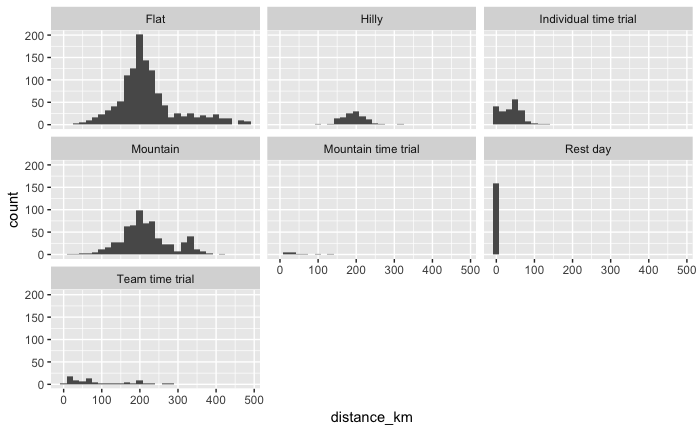

```r
# Parse distance
data_sep <- data_sep %>%
  mutate(distance_km = as.numeric(distance_km))

# Check distribution of distances
data_sep %>%
  ggplot(aes(distance_km)) +
  geom_histogram() +
  facet_wrap(~ terrain_group)
```

Remove redundant variables and ensure parsing of each column is correct.

```r
data_sep <- data_sep %>%
  select(
    stage_id,
    date,
    stage_number,
    sub_stage,
    start_place,
    start_country,
    end_place,
    end_country,
    distance_km,
    terrain,
    terrain_group,
    winner_name,
    winner_country
  )

tour_data <- data_sep

tour_data
```

| stage_id | date | stage_number | sub_stage | start_place | start_country | end_place | end_country | distance_km | terrain | terrain_group | winner_name | winner_country |
| --- | --- | --- | --- | --- | --- | --- | --- | --- | --- | --- | --- | --- |
| 1903_1 | 1903-07-01 | 1 | main | Paris | FR | Lyon | FR | 467.0 | Plain | Flat | Maurice Garin | FRA |
| 1903_2 | 1903-07-05 | 2 | main | Lyon | FR | Marseille | FR | 374.0 | With mountain | Mountain | Hippolyte Aucouturier | FRA |
| 1903_3 | 1903-07-08 | 3 | main | Marseille | FR | Toulouse | FR | 423.0 | Plain | Flat | Hippolyte Aucouturier | FRA |
| 1903_4 | 1903-07-12 | 4 | main | Toulouse | FR | Bordeaux | FR | 268.0 | Plain | Flat | Charles Laeser | SUI |
| 1903_5 | 1903-07-13 | 5 | main | Bordeaux | FR | Nantes | FR | 425.0 | Plain | Flat | Maurice Garin | FRA |
| 1903_6 | 1903-07-18 | 6 | main | Nantes | FR | Paris | FR | 471.0 | Plain | Flat | Maurice Garin | FRA |
| 1904_1 | 1904-07-02 | 1 | main | Montgeron | FR | Lyon | FR | 467.0 | Plain | Flat | Maurice Garin | FRA |
| 1904_2 | 1904-07-09 | 2 | main | Lyon | FR | Marseille | FR | 374.0 | With mountain | Mountain | Hippolyte Aucouturier | FRA |
| 1904_3 | 1904-07-13 | 3 | main | Marseille | FR | Toulouse | FR | 424.0 | Plain | Flat | Hippolyte Aucouturier | FRA |
| 1904_4 | 1904-07-17 | 4 | main | Toulouse | FR | Bordeaux | FR | 268.0 | Plain | Flat | Lucien Pothier | FRA |

[output cut: 990 more lines]

Use geonames open source api to geocode each location.

```r
# Set options for geonames. Need to set host to be api.geonames.org as geonames package default is ws.geonames.org and all addresses have been changed by geonames to api.geonames.org instead of ws.geonames.org and the R geonaes package hasn't ben updated for this.
options(geonamesUsername="sancy8")
options(geonamesHost="api.geonames.org")

# Define function to extract latitude and longitude from top search result from geonames api with bias towards country as recorded in Tour de France data.  Use GNsearch first.
get_gps_gnsearch <- function(place, country) {
  res <-
    GNsearch(
      name = place,
      maxRows = 1,
      country_bias = country,
      continentCode = "EU"
    ) %>%
    select(lat, lng, name, geonameId, population) %>%
    transmute(lng = as.double(lng), lat = as.double(lat), name = as.character(name), gn_id = as.character(geonameId), population = as.double(population))
  return(res)
}

# Get latitude and longitude coordinates for the unique locations in the Tour de France data.
loc_gps_end <- tour_data %>%
  select(starts_with("end_")) %>%
  distinct() %>%
  rename(place = "end_place", country = "end_country")

loc_gps_1 <- tour_data %>%
  select(starts_with("start_")) %>%
  distinct() %>%
  rename(place = "start_place", country = "start_country") %>%
  bind_rows(loc_gps_end) %>%
  distinct()

loc_gps_1 <- loc_gps_1 %>%
  mutate(gps = purrr::map2(place, country, possibly(get_gps_gnsearch, "error")))

# Number of locations which failed to match
loc_gps_1 %>%
  filter(gps == "error")
```

| place | country | gps |
| --- | --- | --- |
| Circuit de Rouen-Les-Essarts | FR |  |
| Circuit de la Prairie, Caen | FR |  |
| Montjuïc circuit | ES |  |
| Merlin-Plage | FR |  |
| Rossignol Voiron | FR |  |
| Mazé-Montgeoffroy | FR |  |
| Morzine Avoriaz | FR |  |
| Domaine du Rouret | FR |  |
| Le Puy du Fou | FR |  |
| Andorra Arcalis | FR |  |

[output cut: 34 more lines]

```r
# Number of locations which failed to match
wiki_gps <- loc_gps_1 %>%
  filter(gps == "error")

# Pluck out values from geonames gps tibble for those that have matched.
loc_gps <- loc_gps_1 %>%
  filter(gps != "error") %>%
  mutate(lat = unlist(pluck(gps, "lat")),
         long = unlist(pluck(gps, "lng")),
         geoname = unlist(pluck(gps, "name")),
         geoname_id = unlist(pluck(gps, "gn_id")),
         population = unlist(pluck(gps, "population"))) %>%
  select(-gps)
```

Attempt to match remaining places using a Wikipedia search

```r
# As above, but use GNwikisearch
get_gps_wikisearch <- function(place) {
  res <-
    GNwikipediaSearch(
      q = place,
      maxRows = 1
    )
  return(res)
}

wiki_gps <- wiki_gps %>%
  mutate(gps = purrr::map(place, possibly(get_gps_wikisearch, "error")))

# Extract lat, long and name values for each place.
tidy_wiki <- function(df){
  df %>%
    as_tibble()%>%
    select(lat, lng, title) %>%
    transmute(lng = as.double(lng), lat = as.double(lat), name = as.character(title), gn_id = "na_wiki", population = NA_real_)
}

wiki_gps <- wiki_gps %>%
  mutate(gps = purrr::map(gps, possibly(tidy_wiki, "error")))

manual_gps <- wiki_gps %>%
  filter(gps == "error")

wiki_gps <- wiki_gps %>%
  filter(gps != "error") %>%
  mutate(lat = unlist(pluck(gps, "lat")),
         long = unlist(pluck(gps, "lng")),
         geoname = unlist(pluck(gps, "name")),
         geoname_id = unlist(pluck(gps, "gn_id")),
         population = unlist(pluck(gps, "population"))) %>%
  select(-gps)
```

Manually edit those which are still not matching.

```r
manual_gps
```

| place | country | gps |
| --- | --- | --- |
| Circuit de la Prairie, Caen | FR |  |
| Domaine du Rouret | FR |  |
| Maubourguet Pays du Val d’Adour | FR |  |
| Belfort/Ballon d’Alsace | FR |  |
| Ballon d’Alsace | FR |  |
| Arenberg Porte du Hainaut | FR |  |
| Gérardmer La Mauselaine | FR |  |
| Saint-Lary Pla d’Adet | FR |  |
| La Caverne du Pont-d'Arc | FR |  |

```r
manual_gps <- manual_gps %>%
  mutate(place_adj = case_when(
    place == "Circuit de la Prairie, Caen" ~ "Caen",
    place == "Domaine du Rouret" ~ "Grospierres",
    place == "Maubourguet Pays du Val d’Adour" ~ "Maubourguet",
    place == "Belfort/Ballon d’Alsace" ~ "Belfort",
    place == "Ballon d’Alsace" ~ "Belfort",
    place == "Arenberg Porte du Hainaut" ~ "Wallers",
    place == "Gérardmer La Mauselaine" ~ "Gérardmer",
    place == "Saint-Lary Pla d’Adet" ~ "Saint-Lary",
    place == "La Caverne du Pont-d'Arc" ~ "Vallon-Pont-d'Arc",
  ))

manual_gps <- manual_gps %>%
  mutate(gps = purrr::map(place_adj, possibly(get_gps_gnsearch, "error"), country = "FR"))

# Check no errors
manual_gps %>%
  filter(gps == "error")
```

| place | country | gps | place_adj |
| --- | --- | --- | --- |

```r
# Extract GPS coordinates
manual_gps <- manual_gps %>%
  filter(gps != "error") %>%
  mutate(lat = unlist(pluck(gps, "lat")),
         long = unlist(pluck(gps, "lng")),
         geoname = unlist(pluck(gps, "name")),
         geoname_id = unlist(pluck(gps, "gn_id")),
         population = unlist(pluck(gps, "population"))) %>%
  select(-gps, -place_adj)
```

Combine GPS coordinates from loc_gps, wiki_gps, manual_gps.

```r
# Combine GPS coordinates
loc_gps <- loc_gps %>%
  bind_rows(wiki_gps, manual_gps)

# Check for any NA values in place to long
loc_gps %>%
  filter(is.na(place) | is.na(country) | is.na(lat) | is.na(long))
```

| place | country | lat | long | geoname | geoname_id | population |
| --- | --- | --- | --- | --- | --- | --- |

```r
# Correct NA values
loc_gps <- loc_gps %>%
  mutate(country = case_when(
    place == "Paris" ~ "FR",
    place == "Utah Beach" ~ "FR",
    place == "Chalet Reynard" ~ "FR",
    TRUE ~ country
  ))

# Check for any NA values in place to long following corrections
loc_gps %>%
  filter(is.na(place) | is.na(country) | is.na(lat) | is.na(long))
```

| place | country | lat | long | geoname | geoname_id | population |
| --- | --- | --- | --- | --- | --- | --- |

Map locations to see if any coordinates that are obviously wrong. There are a few that are obviously wrong.

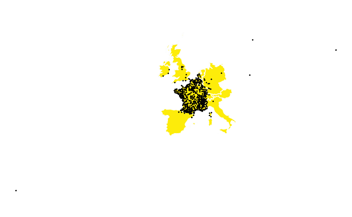

```r
world_map <- map_data(map = "world")

countries <-
  c("Austria",
    "Belgium",
    "France",
    "Germany",
    "Ireland",
    "Italy",
    "Luxembourg",
    "Netherlands",
    "Spain",
    "Switzerland",
    "UK")

borders_map <- map_data(map = "world", region = countries)

borders_plot <- ggplot() +
  geom_polygon(data = borders_map, aes(x = long, y = lat, group = group), fill = "#FEED00", colour = "#FDFEFE") +
  coord_map() +
  theme_void() +
  geom_point(data = loc_gps, aes(x = long, y = lat), size = 0.25, colour = "black")

borders_plot
```

Filter out those outside of GPS boundary enclosing most of the other points.

```r
# Identify incorrect GPS coordinates
gps_error <- loc_gps %>%
  filter(long < -9 | long > 14 | lat < 40| lat > 55)

gps_error
```

| place | country | lat | long | geoname | geoname_id | population |
| --- | --- | --- | --- | --- | --- | --- |
| Brest | FR | 52.09755 | 23.68775 | Brest | 629634 | 300715 |
| Revel | FR | 59.43696 | 24.75353 | Tallinn | 588409 | 394024 |
| Pal | FR | 57.45350 | 55.66170 | Pal' | 513137 | 0 |
| La Pierre Saint-Martin | FR | 18.06030 | -63.06680 | Saint Martin | na_wiki | NA |

```r
# Remove observations in wiki_error from loc_gps
loc_gps <- loc_gps %>%
  anti_join(gps_error, by = "place")

# place_adj and country_adj entered manually by searching place and Tour de France on google and finding nearest location with result on geonames.
gps_error <- gps_error %>%
  mutate(place_adj = case_when(
    place == "Mont des Alouettes" ~ "Les Herbiers",
    place == "La Pierre Saint-Martin" ~ "Accous",
    TRUE ~ place
  ),
  country_adj = case_when(
    place == "Pal" ~ "AD",
    TRUE ~ country
  )
  ) %>%
  select(place, country, place_adj, country_adj)

# Pull gps data from geonames forcing country to be country == country_adj
get_gps_gnsearch_strict <- function(place, country) {
  res <-
    GNsearch(
      name = place,
      maxRows = 1,
      country = country
    ) %>%
    select(lat, lng, name, geonameId, population) %>%
    transmute(lng = as.double(lng), lat = as.double(lat), name = as.character(name), gn_id = as.character(geonameId), population = as.double(population))
  return(res)
}

gps_error <- gps_error %>%
  mutate(gps = purrr::map2(place_adj, country_adj, possibly(get_gps_gnsearch_strict, "error")))

# Check no errors
gps_error %>%
  filter(gps == "error")
```

| place | country | place_adj | country_adj | gps |
| --- | --- | --- | --- | --- |